# **Melchizedek Ackah-Blay**

### **Red Ventures Technical Case**

#### **Thursday, December 12, 2024**

### Project Overview

The goal of the project is to optimize the call-to-action (CTA) strategies used by Financial Services to maximize revenue per user. I plan on approaching this project by analyzing user interactions with various CTA combinations to identify which ones drive the highest engagement and conversions (which in turn will lead to increased revenue). I will also try understanding different user behaviors to help predict the optimal call-to-action (CTA). These processes will help understand the most important factors in generating revenue

### Importing Libraries

```python
# Standard libraries
import pandas as pd
import numpy as np
import matplotlib.pyplot as plt
import matplotlib.style as style
style.use('ggplot')
import seaborn as sns

# Feature engineering libraries
from sklearn.model_selection import train_test_split as t
from sklearn.preprocessing import LabelEncoder, StandardScaler

# Importing warnings to deal with depreciation messages
import warnings as w
w.filterwarnings('ignore')
```

### Loading Dataset

```python
financial_services_data = pd.read_csv(r'/Users/melki/Desktop/_28For_Candidate_29_dspm_case_data_set_-__28For_Candidate_29_dspm_case_data_set.csv')
```

### Exploring Dataset

```python
# Displaying sample rows from the dataset
financial_services_data.sample(4)
```

|  | userId | sessionReferrer | browser | deviceType | estimatedAnnualIncome | estimatedPropertyType | visitCount | pageURL | ctaCopy | ctaPlacement | editorialSnippet | scrolledPage | scrollDepth | clickedCTA | scheduledAppointment | revenue | mortgageVariation |
| --- | --- | --- | --- | --- | --- | --- | --- | --- | --- | --- | --- | --- | --- | --- | --- | --- | --- |
| 49827 | user_96127 | Social | Firefox | Desktop | 130000 | Townhome | 1 | https://www.financialservices.com/mortgages/be... | Get Pre-Approved for a Mortgage in 5 Minutes | Top | Discover the top mortgage lenders of the year.... | 1 | 100 | 1 | 1 | 225 | B |
| 87912 | user_4788 | Google | Chrome | Desktop | 122000 | House | 1 | https://www.financialservices.com/mortgages/ho... | Get Pre-Approved for a Mortgage in 5 Minutes | Bottom | Equip yourself with knowledge. Understand the ... | 1 | 75 | 0 | 0 | 0 | NaN |
| 8713 | user_43304 | Google | Chrome | Desktop | 76000 | House | 1 | https://www.financialservices.com/mortgages/30... | Access Your Personalized Mortgage Rates Now | Bottom | Compare current 30-year mortgage rates from to... | 1 | 100 | 0 | 0 | 0 | NaN |
| 92776 | user_4295 | Google | Safari | Mobile | 150000 | House | 1 | https://www.financialservices.com/mortgages/apply | Get Pre-Approved for a Mortgage in 5 Minutes | Top | Embark on your homeownership journey with our ... | 1 | 100 | 1 | 1 | 275 | C |

```python
# Analyzing shape of the dataset
financial_services_data.shape
```

```
(100000, 17)
```

*There are 100,000 rows and 17 columns in the dataset.*

```python
# Analyzing column information
financial_services_data.info()
```

```
<class 'pandas.core.frame.DataFrame'>
RangeIndex: 100000 entries, 0 to 99999
Data columns (total 17 columns):
 #   Column                 Non-Null Count   Dtype
---  ------                 --------------   -----
 0   userId                 100000 non-null  object
 1   sessionReferrer        100000 non-null  object
 2   browser                100000 non-null  object
 3   deviceType             100000 non-null  object
 4   estimatedAnnualIncome  100000 non-null  int64
 5   estimatedPropertyType  100000 non-null  object
 6   visitCount             100000 non-null  int64
 7   pageURL                100000 non-null  object
 8   ctaCopy                100000 non-null  object
 9   ctaPlacement           100000 non-null  object
 10  editorialSnippet       100000 non-null  object
 11  scrolledPage           100000 non-null  int64
 12  scrollDepth            100000 non-null  int64
 13  clickedCTA             100000 non-null  int64
 14  scheduledAppointment   100000 non-null  int64
 15  revenue                100000 non-null  int64
 16  mortgageVariation      5517 non-null    object
dtypes: int64(7), object(10)
memory usage: 13.0+ MB
```

*The columns in the dataset are either 64-bit integers or strings. This will make it easy to analyze given I do not have to deal with multiple varibale types*.

```python
# Analyzing numeric variables' summary statistics
financial_services_data.describe()
```

|  | estimatedAnnualIncome | visitCount | scrolledPage | scrollDepth | clickedCTA | scheduledAppointment | revenue |
| --- | --- | --- | --- | --- | --- | --- | --- |
| count | 100000.000000 | 100000.000000 | 100000.000000 | 100000.000000 | 100000.000000 | 100000.000000 | 100000.000000 |
| mean | 130654.720000 | 2.225850 | 0.896760 | 62.258500 | 0.172610 | 0.055170 | 12.030350 |
| std | 62345.748304 | 2.070924 | 0.304274 | 30.139065 | 0.377912 | 0.228313 | 51.867358 |
| min | 50000.000000 | 1.000000 | 0.000000 | 0.000000 | 0.000000 | 0.000000 | 0.000000 |
| 25% | 90000.000000 | 1.000000 | 1.000000 | 50.000000 | 0.000000 | 0.000000 | 0.000000 |
| 50% | 117000.000000 | 1.000000 | 1.000000 | 75.000000 | 0.000000 | 0.000000 | 0.000000 |
| 75% | 145000.000000 | 3.000000 | 1.000000 | 75.000000 | 0.000000 | 0.000000 | 0.000000 |
| max | 400000.000000 | 10.000000 | 1.000000 | 100.000000 | 1.000000 | 1.000000 | 375.000000 |

*The above dataframe provides a count, mean, standard deviation, minimum value, percentile ranges, and maximum value summary for the numeric columns.*

```python
# Addresssing null values
financial_services_data.isna().sum()
```

```
userId                       0
sessionReferrer              0
browser                      0
deviceType                   0
estimatedAnnualIncome        0
estimatedPropertyType        0
visitCount                   0
pageURL                      0
ctaCopy                      0
ctaPlacement                 0
editorialSnippet             0
scrolledPage                 0
scrollDepth                  0
clickedCTA                   0
scheduledAppointment         0
revenue                      0
mortgageVariation        94483
dtype: int64
```

*94.5% of the data in the 'mortgageVariation' are* *null**. This renders the column unreliable for analysis or meachine learning.*

```python
# Addressing duplicated rows
financial_services_data.duplicated().sum()
```

```
0
```

*100% of the rows in the data are* *unique** (there are no duplicated rows).*

```python
# Duplicating the dataset
financial_data = financial_services_data.copy()
```

*Duplicating the dataset makes it easier to correct mistakes further into analysis. The duplicated dataset protects from permanently altering the orgiinal dataset. Also, it will be important for side by side comparison will the original data in case of doubts.*

### Exploratory Data Analysis

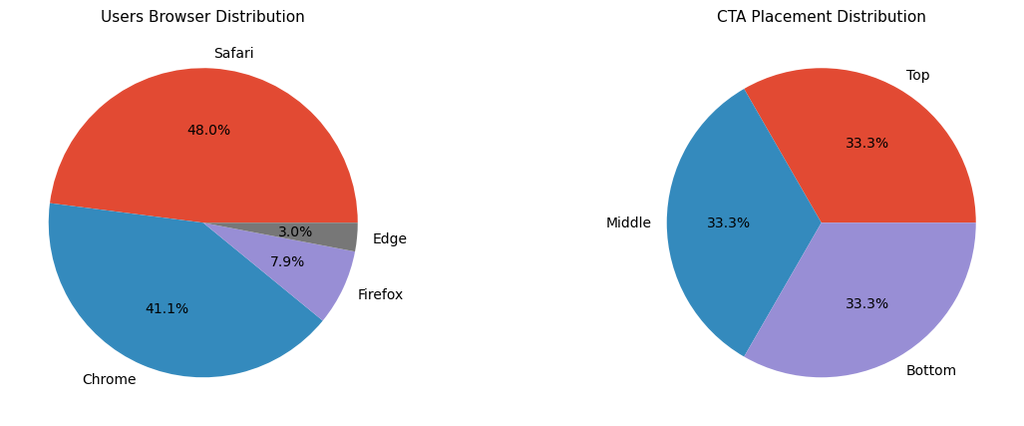

```python
# Distribution of browsers used by site visitors AND CTA Placement Distribution

plt.figure(figsize = (13,13))
plt.subplot(1,2,1)
browser_distribution = financial_data['browser'].value_counts(ascending = False)
browser_distribution.head(5).plot(kind = 'pie', autopct = '%1.1f%%')
plt.title('Users Browser Distribution', fontsize = 11)
plt.xlabel('')
plt.ylabel('')

plt.subplot(1,2,2)
browser_distribution = financial_data['ctaPlacement'].value_counts(ascending = False)
browser_distribution.head(5).plot(kind = 'pie', autopct = '%1.1f%%')
plt.title('CTA Placement Distribution', fontsize = 11)
plt.xlabel('')
plt.ylabel('')
plt.subplots_adjust(wspace = 0.6)
plt.show()
```

**Re: Browser Distribution**

*Almost 90% of Financial Services' users use either Safari or Chrome. The remaining browse the site from Edge or Firefox. This site is unsurprising nonetheless because Chrome and Safari are the most used browsers worldwide. It is however important to show stakeholders for them to understand where users access the site from.*

**Re: CTA Placement Distribution**

*The click-to-action buttons were represented at* *33.3%** each. This is a step in reducing bias from Financial Services' perspective*

```python
# Distribution of user devices
user_device_distribution = pd.DataFrame(financial_data['deviceType'].value_counts(normalize = True))
user_device_distribution.columns = ['Number of Users']
user_device_distribution
```

| deviceType | Number of Users |
| --- | --- |
| Mobile | 0.60034 |
| Desktop | 0.39966 |

*60% of users browse Financial Services' website from a mobile phone whereas the reamining 40% browse the site from a desktop computer. The split is not too drastic and is likened to that of competitor (Source: Analytive.com)*

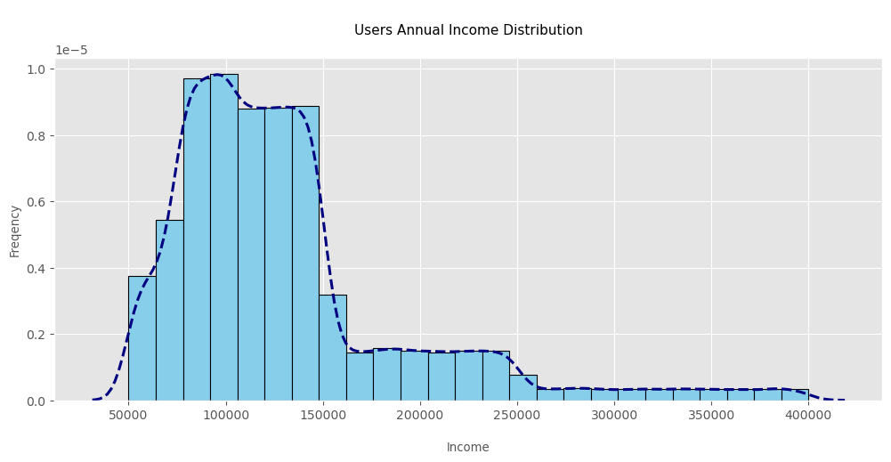

```python
# Users annual income distribution
plt.figure(figsize = (12, 5))
plt.hist(financial_data['estimatedAnnualIncome'], edgecolor = 'black', linewidth = 0.8, color = 'skyblue', density = True, bins = 25)
sns.kdeplot(financial_data['estimatedAnnualIncome'], color = 'navy', linewidth = 2.2, linestyle = '--')
plt.title('\nUsers Annual Income Distribution\n', fontsize = 11)
plt.xlabel('\nIncome', fontsize = 9.5)
plt.ylabel('Freqency', fontsize = 9.5)
plt.show()
```

*Amongst visitors of the Financial Services website, an overwhelming majority make* *150k or less**, with the upper echelon of users in the* *350k to 400k** income range.*

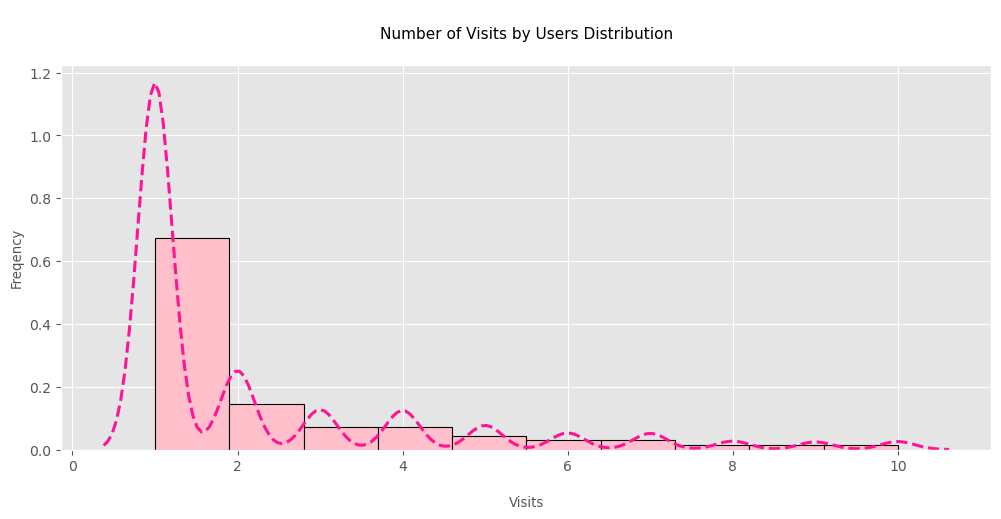

```python
# Users visits distribution
plt.figure(figsize = (12, 5))
plt.hist(financial_data['visitCount'], edgecolor = 'black', linewidth = 0.8, color = 'pink', density = True, bins = 10)
sns.kdeplot(financial_data['visitCount'], color = 'deeppink', linewidth = 2.2, linestyle = '--')
plt.title('\nNumber of Visits by Users Distribution\n', fontsize = 11)
plt.xlabel('\nVisits', fontsize = 9.5)
plt.ylabel('Freqency', fontsize = 9.5)
plt.show()
```

***Over 60%** of users visited Financial Services' website **just once**, a select few (about 12%) visited **twice**, and it decreases from there.*

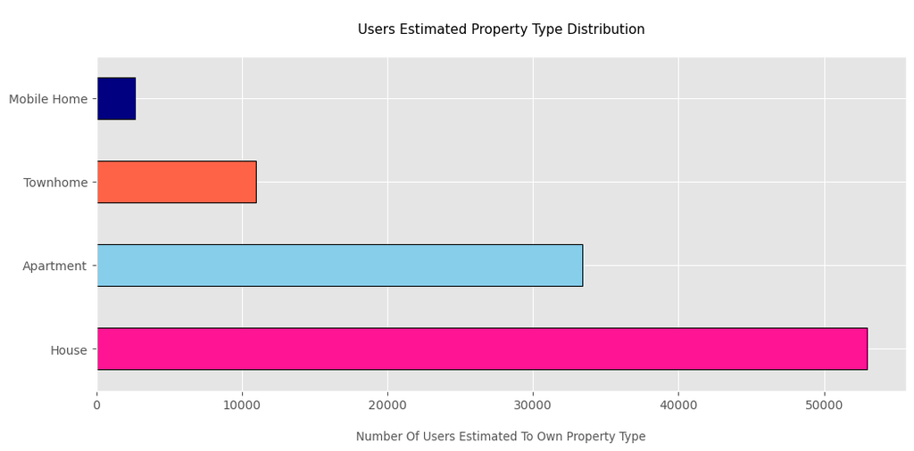

```python
# Property Type of Users
plt.figure(figsize = (12, 5))
financial_data['estimatedPropertyType'].value_counts().plot(kind = 'barh', edgecolor = 'black', linewidth = 0.8, color = ['deeppink', 'skyblue', 'tomato', 'navy', 'peachpuff','forestgreen'])
plt.title('\nUsers Estimated Property Type Distribution\n', fontsize = 11)
plt.xlabel('\nNumber Of Users Estimated To Own Property Type', fontsize = 9.5)
plt.ylabel('')
plt.show()
```

*Majority of users were estimated to live in either a* *house** or an **apartment**. I am quite shocked at the low count for **town homes**. I expected it to be a bit larger than that.*

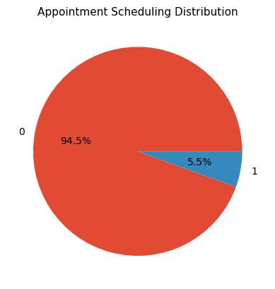

```python
# Distribution of users who scheduled an appointment
appointment_scheduling_distribution = financial_data['scheduledAppointment'].value_counts(ascending = False)
appointment_scheduling_distribution.plot(kind = 'pie', autopct = '%1.1f%%')
plt.title('Appointment Scheduling Distribution', fontsize = 11)
plt.xlabel('')
plt.ylabel('')
plt.show()
```

*Overwhelming majority of users who visited the Financial Services website* *did not** schedule an appointment. Only a mere **5.5%** did.*

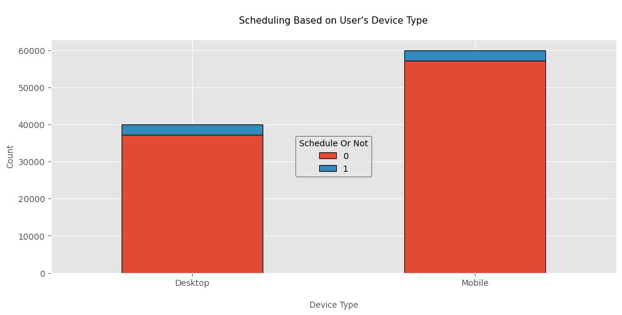

```python
# Appointment scheduling by device
scheduling_by_device = financial_data.groupby(['deviceType', 'scheduledAppointment'])['scheduledAppointment'].count().unstack()
scheduling_by_device.plot(kind = 'bar', stacked = True, edgecolor = 'black', linewidth = 0.8, figsize = (12,5))
plt.title("\nScheduling Based on User's Device Type\n", fontsize = 11)
plt.xlabel('\nDevice Type', fontsize = 9.5)
plt.xticks(rotation = 0)
plt.ylabel('Count', fontsize = 9.5)
plt.legend(loc = 'center', edgecolor = 'black', title = 'Schedule Or Not')
plt.show()
```

*Regardless of device type,* *only a few** numbers of users scheduled an interview. although **not conclusive on its own**, it opens up the question, 'Does the type of device users use to access Financial Services' website matter?'*

### Project Question 1: Exploring The Split Test

```python
# Grouping data by click to action and click to action placement
split_test_metrics = financial_data.groupby(['ctaCopy', 'ctaPlacement']).agg(
    total_impressions = ('userId', 'count'),
    total_clicks = ('clickedCTA', 'sum'),
    total_appointments = ('scheduledAppointment', 'sum'),
    total_revenue = ('revenue', 'sum')
).reset_index()

split_metrics_dataframe = pd.DataFrame(split_test_metrics)
split_metrics_dataframe.columns = ['click-to-action text', 'click-to-action placement', 'total impressions', 'total clicks', 'total appointments', 'total revenue']
split_metrics_dataframe
```

|  | click-to-action text | click-to-action placement | total impressions | total clicks | total appointments | total revenue |
| --- | --- | --- | --- | --- | --- | --- |
| 0 | Access Your Personalized Mortgage Rates Now | Bottom | 11111 | 1498 | 575 | 125915 |
| 1 | Access Your Personalized Mortgage Rates Now | Middle | 11111 | 1794 | 563 | 126935 |
| 2 | Access Your Personalized Mortgage Rates Now | Top | 11111 | 2072 | 607 | 134675 |
| 3 | First Time? We've Made it Easy to Find the Bes... | Bottom | 11111 | 1701 | 632 | 143390 |
| 4 | First Time? We've Made it Easy to Find the Bes... | Middle | 11111 | 1888 | 591 | 134125 |
| 5 | First Time? We've Made it Easy to Find the Bes... | Top | 11111 | 2205 | 606 | 136520 |
| 6 | Get Pre-Approved for a Mortgage in 5 Minutes | Bottom | 11111 | 1713 | 630 | 129970 |
| 7 | Get Pre-Approved for a Mortgage in 5 Minutes | Middle | 11111 | 2037 | 643 | 130595 |
| 8 | Get Pre-Approved for a Mortgage in 5 Minutes | Top | 11112 | 2353 | 670 | 140910 |

*Given that I want to find out which* *click to action text** and **button placement** combination by Financial Services performed the best, I grouped the data on **ctaCopy** (the variable corresponding to the click-to-action text(, and **ctaPlacement** (the variable corresponding to the click-to-action button placement). I did not want just the count for each combination of text and button placement, but rather a **quantifiable metric** to measure their the efficiency of each split.*

*I proceeded to group the variables by the count of* *userId** (the user's unique identification) to get the number of impressions per combination.*

*Secondly, I grouped the variables by* *clickedCTA** (click or not variable) to get the number of clicks per combination.*

*Thirdly, I grouped the variables by* *scheduledAppointment** (scheduled an appointment or not).*

*Lastly, I grouped by* *revenue** to get the total revenue per combination*

```python
# Analyzing which split/combination is the best by using customized metrics
split_test_metrics['CTR (%)'] = (split_test_metrics['total_clicks'] / split_test_metrics['total_impressions']) * 100
split_test_metrics['Conversion Rate (%)'] = (split_test_metrics['total_appointments'] / split_test_metrics['total_clicks']) * 100
split_test_metrics['Revenue per User'] = split_test_metrics['total_revenue'] / split_test_metrics['total_impressions']

# Selecting the best combination of button placement and text
best_combination = split_test_metrics.sort_values('Revenue per User', ascending=False).head(1)

# Calculating average revenue from all the combinations
average_revenue = split_test_metrics['Revenue per User'].mean()

best_combination[['ctaCopy', 'ctaPlacement', 'Revenue per User']]
```

|  | ctaCopy | ctaPlacement | Revenue per User |
| --- | --- | --- | --- |
| 3 | First Time? We've Made it Easy to Find the Bes... | Bottom | 12.905229 |

*The* *best combination** of click-to-action button placement and click-to-action text is having the phrase "**First Time? We've Made it Easy to Find the Best Mortgage Rate**" and the button at the **bottom**.*

```python
# Calculating incremental worth supposed we stick to the best combination

# Incremental worth = (best combination revenue - average revenue) * the number of users
incremental_worth = (best_combination['Revenue per User'] - average_revenue) * financial_data.shape[0]
incremental_worth
```

```
3    87488.555771
Name: Revenue per User, dtype: float64
```

*If Financial Services sticks to the best combination above, it would be worth* *87,488.55** in revenue.*

### Project Question 2: Site Users and Behavior Analysis

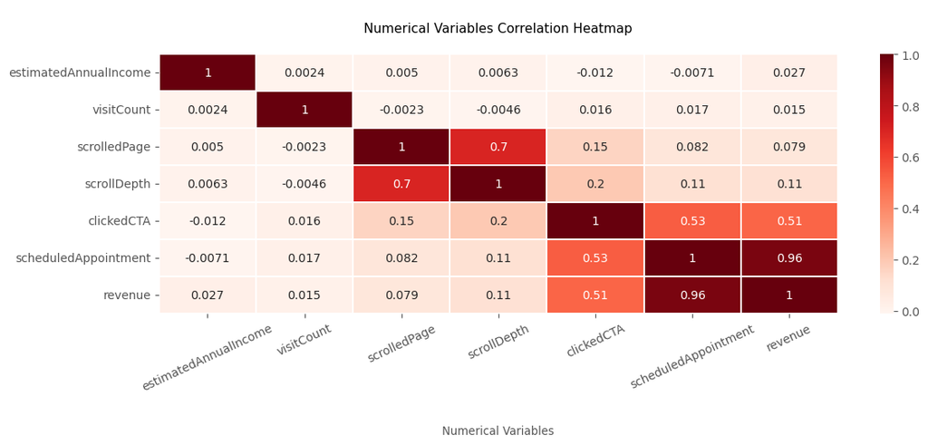

```python
# correlation analysis
numerical_variables = financial_data.select_dtypes(include = 'int')
correlation_matrix = numerical_variables.corr()
plt.figure(figsize = (13, 4))
sns.heatmap(correlation_matrix, cmap = 'Reds', annot=True, linewidth = 1.2)
plt.title("\nNumerical Variables Correlation Heatmap\n", fontsize = 11)
plt.xlabel('\n\nNumerical Variables', fontsize = 9.5)
plt.xticks(rotation = 25)
plt.show()
```

*The results of the correlation heatmap tell us a lot about users and their behaviors:*

***1.** There is a moderately strong linear correlation between **scrollDepth** and **scrollPage**. Users who scrolled a page were likely to scroll for a while longer (scroll depth).*

***2.** There is a moderately positive linear relationship between **clickedCTA** and **revenue**. Users who clicked the call-to-action button were a bit likely to generate revenue for Financial Services.**

***3.** There is a moderately positive linear relationship between **clickedCTA** and **scheduledAppointment**. Users who clicked the call-to-action button were a bit likely to schedule an appoitment.**

***4.** There is a strong positive linear relationship between **scheduledAppointment** and **revenue**. Users who scheduled appointment were **very likely** to generate revenue for Financial Services.*

```python
# Function to categorize users by estimated annual income
def income_categories(user_estimated_income):
    if user_estimated_income < 50000:
        return 'Low Class'
    elif 50000 <= user_estimated_income < 120000:
        return 'Middle Class'
    elif 120000 <= user_estimated_income < 350000:
        return 'High Class'
    else:
        return 'Upper Class'

# creating a new column using the income data
temp_financial_data = financial_data.copy()
temp_financial_data['incomeGrouped'] = financial_data['estimatedAnnualIncome'].apply(income_categories)
```

*The function above categorizes user incomes class by:* *low**,* *middle**,* *high**,* *upper**. This makes it easier to visualize income groups using* *groupby**.*

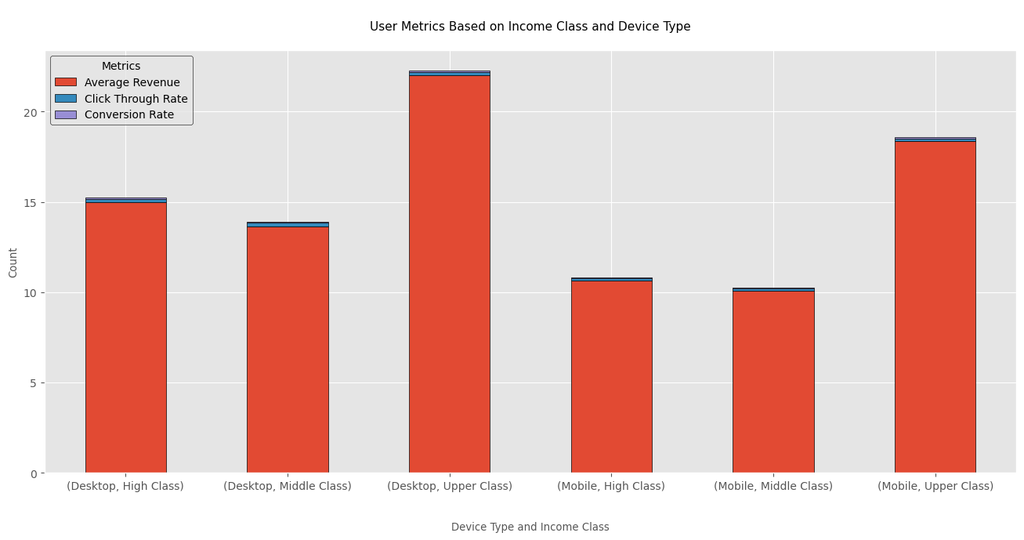

```python
# User device and income Analysis
device_income_analysis = temp_financial_data.groupby(['deviceType', 'incomeGrouped']).agg(
    avg_revenue=('revenue', 'mean'),
    CTR=('clickedCTA', 'mean'),
    conversion_rate=('scheduledAppointment', 'mean')
).reset_index()

device_income_analysis = device_income_analysis.set_index(['deviceType', 'incomeGrouped'])
device_income_analysis.plot(kind = 'bar', stacked = True, figsize = (16, 7), edgecolor = 'black')
plt.title('\nUser Metrics Based on Income Class and Device Type\n', fontsize = 11)
plt.xlabel('\n\nDevice Type and Income Class', fontsize = 9.5)
plt.xticks(rotation = 0)
plt.ylabel('Count', fontsize = 9.5)
plt.legend(edgecolor = 'black', labels = ['Average Revenue', 'Click Through Rate', 'Conversion Rate'], title = 'Metrics', loc = 'upper left')
plt.show()
```

*The visualization above depicts users based on their* *device type** and **income class** as well as been evaluate using established metrics*

```python
# adding a column to improve predictive power
temp_financial_data['ctaGrouped'] = temp_financial_data['ctaCopy'] + " - " + temp_financial_data['ctaPlacement']
```

*This column combines the* *click-to-action text** and the **click-to-action placement**. It can be likened to a column containing grouped data. By doing this I can leverage the effectiveness of **groupby** to create meaningful insights to manufacture a new column that has more predictor power than the text or button columns on their own*

```python
# adding another column to improve predictive power
def scroll_categories(scroll):
    if scroll > 50:
        return 1
    else:
        return 0
temp_financial_data['scrollEngagement'] = temp_financial_data['scrollDepth'].apply(scroll_categories)
temp_financial_data['scrollEngagement'].unique()
```

```
array([1, 0])
```

*I initially wanted the cutoff to be 75 but that would not be a good representation of the data*

### Project Question 3: Predicting Optimal CTA to maximize revenue

##### Feature Engineeering

```python
# dropping 'mortgageVariation' columns
f_services_data = temp_financial_data.copy()
f_services_data.drop(columns = ['mortgageVariation','userId'], inplace = True)
```

*The '**mortgageVariation**' column has over 90%* null values* therefore I will not consider it for model building*

*The '**userID**' column is strictly for individual user identification and row count there I will not consider it for model building*

```python
# Label encoding categorical variables in the dataset
```

```python
encoder = LabelEncoder()
f_services_data['sessionReferrer'] = encoder.fit_transform(f_services_data['sessionReferrer'])
f_services_data['browser'] = encoder.fit_transform(f_services_data['browser'])
f_services_data['deviceType'] = encoder.fit_transform(f_services_data['deviceType'])
f_services_data['estimatedPropertyType'] = encoder.fit_transform(f_services_data['estimatedPropertyType'])
f_services_data['pageURL'] = encoder.fit_transform(f_services_data['pageURL'])
f_services_data['ctaCopy'] = encoder.fit_transform(f_services_data['ctaCopy'])
f_services_data['ctaPlacement'] = encoder.fit_transform(f_services_data['ctaPlacement'])
f_services_data['editorialSnippet'] = encoder.fit_transform(f_services_data['editorialSnippet'])
f_services_data['incomeGrouped'] = encoder.fit_transform(f_services_data['incomeGrouped'])
f_services_data['ctaGrouped'] = encoder.fit_transform(f_services_data['ctaGrouped'])
```

```python
# Verifying if the encoding worked
f_services_data.head(3)
```

|  | sessionReferrer | browser | deviceType | estimatedAnnualIncome | estimatedPropertyType | visitCount | pageURL | ctaCopy | ctaPlacement | editorialSnippet | scrolledPage | scrollDepth | clickedCTA | scheduledAppointment | revenue | incomeGrouped | ctaGrouped | scrollEngagement |
| --- | --- | --- | --- | --- | --- | --- | --- | --- | --- | --- | --- | --- | --- | --- | --- | --- | --- | --- |
| 0 | 2 | 3 | 1 | 152000 | 0 | 1 | 8 | 1 | 1 | 26 | 1 | 75 | 0 | 0 | 0 | 0 | 4 | 1 |
| 1 | 3 | 3 | 1 | 140000 | 0 | 2 | 4 | 0 | 0 | 8 | 1 | 25 | 0 | 0 | 0 | 0 | 0 | 0 |
| 2 | 0 | 3 | 1 | 128000 | 1 | 1 | 3 | 0 | 0 | 16 | 1 | 75 | 0 | 0 | 0 | 0 | 0 | 1 |

```python
# Splitting dataset into X and Y
X = f_services_data.drop(columns = ['revenue'])
y = f_services_data['revenue']
```

##### Feature Engineeering

```python
from sklearn.feature_selection import SelectKBest, chi2
selector = SelectKBest(score_func = chi2, k = 10)
selected_X = selector.fit_transform(X, y)

# Getting selected columns
mask = selector.get_support()
selected_columns = X.columns[mask]
print("Selected Features:", selected_columns)
```

```
Selected Features: Index(['sessionReferrer', 'estimatedAnnualIncome', 'pageURL', 'scrolledPage',
       'scrollDepth', 'clickedCTA', 'scheduledAppointment', 'incomeGrouped',
       'ctaGrouped', 'scrollEngagement'],
      dtype='object')
```

*Feature Selection is the* *BIGGEST STEP** in feature engineering in my opinion.*

*Given that, the features you select will directly impace how your model(s) perform. It is also* *critical** not to select too many features or too little.*

```python
# Engineered X features/columns
X_select = f_services_data[['sessionReferrer', 'estimatedAnnualIncome', 'pageURL', 'scrolledPage',
       'scrollDepth', 'clickedCTA', 'scheduledAppointment', 'incomeGrouped',
       'ctaGrouped', 'scrollEngagement']]
X_select.sample(3)
```

|  | sessionReferrer | estimatedAnnualIncome | pageURL | scrolledPage | scrollDepth | clickedCTA | scheduledAppointment | incomeGrouped | ctaGrouped | scrollEngagement |
| --- | --- | --- | --- | --- | --- | --- | --- | --- | --- | --- |
| 73934 | 3 | 70000 | 7 | 1 | 50 | 0 | 0 | 1 | 2 | 0 |
| 52567 | 0 | 117000 | 1 | 1 | 100 | 0 | 0 | 1 | 4 | 1 |
| 92234 | 2 | 87000 | 1 | 1 | 75 | 0 | 0 | 1 | 6 | 1 |

```python
# Splitting data into train and test
X_train, X_test, y_train, y_test = t(X_select, y, test_size = 0.2, random_state = 42)
```

```python
# Scaling X values
scaler = StandardScaler()
X_train_scaled = scaler.fit_transform(X_train)
X_test_scaled = scaler.fit_transform(X_test)
```

*Scaling X features is important because it brings all of them down to the same range, with 0 at the center. This ensures all the features contribute equally to the model*

##### Model Training

```python
# creating function to evaluate models
from sklearn.metrics import mean_squared_error, mean_absolute_error, r2_score
def evaluator(predictions):
    print(f'Mean Squared Error: {mean_squared_error(y_test, predictions)}')
    print(f'Mean Absolute Error: {mean_absolute_error(y_test, predictions)}')
    print(f'R Squared Value: {r2_score(y_test, predictions)}')
```

```python
# Getting libraries
from sklearn.ensemble import RandomForestRegressor
from sklearn.model_selection import GridSearchCV

p = {
    'n_estimators': [100, 200, 500],
    'max_depth': [None, 10, 20, 30],
    'min_samples_split': [2, 5, 10],
}

# Training model
grid_rf = GridSearchCV(RandomForestRegressor(), param_grid = p, cv = 5)
grid_rf.fit(X_train_scaled, y_train)
```

```
GridSearchCV(cv=5, estimator=RandomForestRegressor(),
             param_grid={'max_depth': [None, 10, 20, 30],
                         'min_samples_split': [2, 5, 10],
                         'n_estimators': [100, 200, 500]})
```

```python
# Analyzing best hyperparameters
grid_rf.best_params_
```

```
{'max_depth': 10, 'min_samples_split': 10, 'n_estimators': 500}
```

```python
# Create model predictor variable
grid_rf_pred = grid_rf.predict(X_test_scaled)

# Evaluating model
evaluator(grid_rf_pred)
```

```
Mean Squared Error: 162.93567178876862
Mean Absolute Error: 2.432575707805806
R Squared Value: 0.9424339095542209
```

**PERFORMANCE COMMENTS**

I am relieved at how **great** the model performed!

I decided to go with a RandomForestRegressor model which is an ensemble model. RandomForestRegressor unlike its base counterpart, **DecisionTreeRegressor**, trains multiple trees sequentially as opposed to one. This makes it way more efficient.

On top of that, I trained the model using **GridSearch**. GridSearch allows you to fine-tune your model using custom hyperparameters. It is important to keep the **curse of dimensionality in mind**. As a result, I decided to have few options per hyperparameter

The model can still be improved! I can retrain with new hyperparameters or train other models and compare the results. The assignment does not say anything about training more than one model, so I am a bit weary, nonetheless

**MODEL RESULTS INTERPRETATION**

**Mean Squared Error**: The mean squared error of the model was 162.93 (2 decimal places) refers to the average squared difference between the predicted revenues and the actual revenues

**Mean Absolute Error**: The mean squared error of the model was 2.43 (2 decimal places) refers to the average absolute difference between the predicted revenues and the actual revenues

**R-Squared**: The R-Squared value of 0.9424 (4 decimal places) means that model is able to explain 94.24% of the variability in the revenue values which is **excellent**

#### MODEL FEATURE IMPORTANCE

```python
grid_model = grid_rf.best_estimator_

# Getting feature importance
feature_importances = pd.DataFrame({'Feature': X_select.columns, 'Importance': grid_model.feature_importances_})
feature_importances = feature_importances.sort_values('Importance', ascending=False)
feature_importances
```

|  | Feature | Importance |
| --- | --- | --- |
| 6 | scheduledAppointment | 0.959136 |
| 1 | estimatedAnnualIncome | 0.030046 |
| 8 | ctaGrouped | 0.004083 |
| 2 | pageURL | 0.003315 |
| 0 | sessionReferrer | 0.001591 |
| 4 | scrollDepth | 0.001457 |
| 9 | scrollEngagement | 0.000298 |
| 7 | incomeGrouped | 0.000074 |
| 3 | scrolledPage | 0.000000 |
| 5 | clickedCTA | 0.000000 |

**FEATURE IMPORTANCE INTERPRETATION**

The features with the **most importance** when it comes to Financial Services' revenue are:

- If a user scheduled an appointment (**scheduledAppointment**): This feature had an importance score of 0.959. Financial Services should take appointment scheduling very seriously. Perhaps, improve the UI of the appointment scheduling page and also make the webpage user-friendly and easy to use. Users should not be confused as to what the appointment scheduling page does.
- The estimated annual income of a user (**estimatedAnnualIncome**): The estimated annual income of users has the second highest importance score. Financial Services mustn't discriminate against individuals of certain income groups because it clearly matters a lot.
- The specific combination of click-to-action button and click-to-action text (**ctaGrouped**): Not only do combinations work well together as per my analysis earlier. It is an important metric. Financial Services should select the top two combinations and experiment with them via A/B testing.
- The type of Finance Services URL the user interacts with (**pageURL**): This really shocked me because I thought the URL would not have much of an influence than the content of the URL itself. I recommend Financial Services try an A/B test using the top two most profitable URLs. Based on the results, they should make advertisements on select media outlets with a link to the best URL.

**ANALYZING COMBINATION THAT GIVES THE MAX REVENUE**

```python
# Find the index of the maximum value in y_test
max_index = y_test.idxmax()

# Get the corresponding X_test row that matches this index
matching_x_value = X_test.loc[max_index]

print("The X_test values corresponding to the max y_test value are:")
print(matching_x_value)
```

```
The X_test values corresponding to the max y_test value are:
sessionReferrer               2
estimatedAnnualIncome    137000
pageURL                       2
scrolledPage                  1
scrollDepth                 100
clickedCTA                    1
scheduledAppointment          1
incomeGrouped                 0
ctaGrouped                    0
scrollEngagement              1
Name: 76699, dtype: int64
```

**MY VERDICT**

So the top 4 important features for revenue based on my model were: If the individual scheduled an appointment, estimated annuanl income, page URL user visited, and click-to-action combination.

This is how the individual who brought in the highest revenue in the testing portion of the data lined up:

Having an appointment scheduled was another critical factor in driving revenue. This indicates that users who are more committed (by scheduling appointments) are more likely to make a decision or purchase. This highlights the importance of converting leads into committed prospects by encouraging them to book appointments or engage further.

**3. Annual Income: 137,000**

Individuals with a higher annual income, particularly around $137,000, are more likely to generate higher revenue per decision. This suggests that wealthier individuals may be more inclined to invest in mortgage solutions, possibly due to higher purchasing power or the need for premium financial services.

**4. PageURL: "https://www.financialservices.com/mortgages/best-mortgage-lenders"**

Users who visited the specific page dedicated to listing the best mortgage lenders were more likely to generate higher revenue. This implies that the content on this page is highly relevant and effective in attracting users who are serious about exploring mortgage options.

**BUSINESS INSIGHTS**

To further optimize their site for higher revenue margins, Financial Services should:

**3.** Focus on higher-income individuals in your campaigns, as they tend to have a higher propensity to generate revenue.

**4.** Optimize content and advertising on key landing pages, such as the one highlighting the best mortgage lenders, which is correlated with high-revenue decisions.

**By focusing on these factors, you could potentially maximize revenue and improve the overall user experience by aligning content and engagement strategies with the behaviors of the most lucrative users.**